# Analítica Avanzada de Datos

Caso #3

Autor/a

Afiliación

[Jorge I. Vélez, PhD - Julian Acevedo](https://jorgeivanvelez.netlify.app/)

Universidad del Norte, Barranquilla

Fecha de publicación

7 de junio de 2024

## Introducción

Los ARN no codificantes largos (lncRNAs en inglés) comprenden un vasto repertorio de ARN que desempeñan una amplia variedad de funciones cruciales en la fisiología de los tejidos de manera específica para cada célula. A pesar de estar implicados en miles de mecanismos reguladores, todavía no se ha asignado ninguna función a muchos lncRNAs.

[figure not shown]

Clasificación de las funciones de los lncRNAs. Imagen tomada de [aquí](https://onlinelibrary.wiley.com/doi/10.1111/jcmm.13238).

Cada vez hay más pruebas de que los lncRNAs se expresan de forma aberrante en la progresión de la [Enfermedad de Alzheimer](https://www.mayoclinic.org/es/diseases-conditions/alzheimers-disease/symptoms-causes/syc-20350447) (EA). En nuestro grupo, hemos analizado la expresión de cientos de lncRNAs en 15 individuos diagnosticados con EA, y 15 voluntarios sin la enfermedad en el marco del proyecto de investigación “*Nuevos ARN no codificantes exo- somales y su papel en la patogénesis de la Enfermedad de Alzheimer*”, código 121584468097 (844/2019), contract 416-2020, otorgado al *Grupo en Genética y Medicina Molecular* (Departamento de Medicina), y al *Grupo de Productividad y Competitividad* (Departamento de Ingeniería Industrial) de la Universidad del Norte, Barranquilla, Colombia.

Una muestra de los datos puede obtenerse haciendo:

```r
## disponibilidad del paquete data.table
if(!require(data.table)) install.packages('data.table')
require(data.table)

## lectura de datos con fread() de data.table
url <- 'https://www.dropbox.com/scl/fi/osljigmhxwcriewhpxq1s/AD_lncRNAs.txt?rlkey=j8cfuqsx51uz9hp3a7qvbzhst&dl=1'
d <- fread(url, header = TRUE)
d <- as.data.frame(d)
```

Las variables relevantes son

- `id`: identificador del participante.
- `dx`: diagnóstico del participante (`0`: no EA; `1`: EA)
- `x1`, `x2`,…, `x29809`: niveles de expresión del lncRNA $j$, con $j=1,2,\ldots,29809$.

El objeto `d` tiene 30 filas y 29811 columnas.

**Importante**

A partir de los datos, el objetivo es **identificar los lncRNAs** cuya expresión *incrementa* o *reduce* la probabilidad de diagnóstico de EA.

**Fecha de entrega:** Junio 11, 2024.

Como la variable respuesta es binaria, podemos utilizar las funciones que ya hemos empleado con anterioridad en Regresión Logística (RL) para medir el desempeño del modelo.

```r
## load functions
source('https://www.dropbox.com/s/xclvdugfbrf5ryn/logistic-functions.R?dl=1')
```

```
This is a collection of functions created by
Professor Jorge Vélez, PhD <https://jorgeivanvelez.netlify.app/>
for the fitting and validation of Binary Classification models

In case of problems, please an email to
<jvelezv@uninorte.edu.co> with enough details

Last modification:  April 23, 2024
```

## Preguntas

### P1

Use una prueba $t$ de Student de 2 colas para identificar los lncRNAs diferencialmente expresados en personas con EA. Extraiga el valor $p$ y compárelo con el nivel de significancia $\alpha = 0.05$. Cuántos de estos son estadísticamente significativos? Use la función `p.adjust()` para ajustar los valores $p$ utilizando el método [FDR](https://www.split.io/glossary/false-discovery-rate/). Compare.

**Respuesta.**

#### Segmentación del dataset

Se toma un set de datos para los individuos diagnosticadas con la enfermedad y se toma otra set de datos con los individuos que no estan diagnosticadas con la enfermedad.

```r
#Segmentar grupos EA y grupo control
grupo_ea <- subset(d, dx == 1)
grupo_control <- subset(d, dx == 0)
```

#### Prueba T Studen de dos colas

Determinaremos si hay una diferencia significativa entre las medias de dos grupos independientes.

Hipotesis:

$H_{0}:\mu_{EA}=\mu_{Control}$

$H_{1}:\mu_{EA}\neq\mu_{Control}$

```r
# prueba t de dos colas
t.test(grupo_ea[3],grupo_control[3],alternative = "two.sided")
```

```
    Welch Two Sample t-test

data:  grupo_ea[3] and grupo_control[3]
t = -0.35285, df = 23.713, p-value = 0.7273
alternative hypothesis: true difference in means is not equal to 0
95 percent confidence interval:
 -0.4203785  0.2976934
sample estimates:
mean of x mean of y
 3.395150  3.456493
```

Tomando como ejemplo la columna $x_{1}$ podemos identificar que el p-valor es igual a 0.7273, este valor es mayor al nivel de significancia del 5% ($\alpha=0.05$, por lo tanto no hay evidencia para rechazar $H_{0}$ y se puede concliur que no hay una diferencia significativa en las medias para la variable $x_{1}$ entre los individuos diagnosticados con la enfermedad (EA) y los individuos diagnoticados sin la enfermedad (Control).

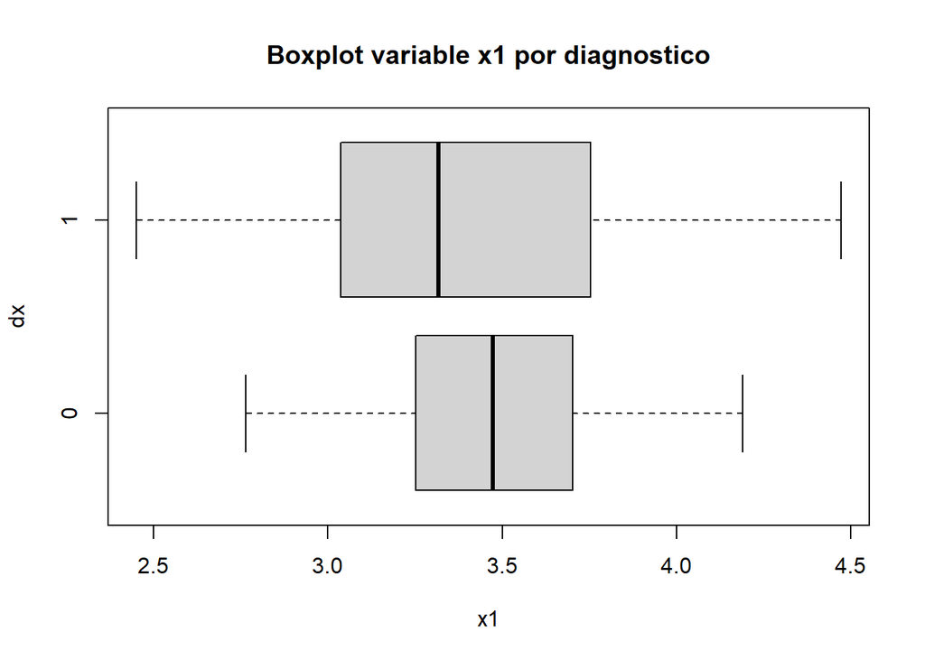

```r
# Grafico boxplot
boxplot(d$x1~d$dx, horizontal = T, xlab = 'x1',ylab = 'dx',main='Boxplot variable x1 por diagnostico')
```

En la figura anterior se logra identificar graficamente las diferencias entre los individuos diagnosticados con la enfermedad (EA) y los individuos diagnoticados sin la enfermedad (Control).

A continuacion se realizara la prueba t de student para cada uno de los 29.809 niveles de expresion del IncRNA

```r
# Resultados
res <- data.frame(lncRNA=character(), p_valor=numeric(), stringsAsFactors=FALSE)
# prueba t para cada nivel
for (col in colnames(d)[3:ncol(d)]){
  test <- t.test(grupo_ea[[col]], grupo_control[[col]], alternative="two.sided")
  res <- rbind(res, data.frame(lncRNA=col, p_valor=test$p.value))
}
```

```r
head(res)
```

```
  lncRNA      p_valor
1     x1 0.7273178923
2     x2 0.6163451816
3     x3 0.0008774605
4     x4 0.8337503626
5     x5 0.4156953303
6     x6 0.0133455919
```

#### Ajuste P-Valor

Cuando se realizan múltiples pruebas estadísticas, como en el análisis de expresión génica donde se prueban cientos o miles de genes al mismo tiempo, la probabilidad de obtener falsos positivos aumenta.

##### Método FDR (False Discovery Rate)

El método fdr se refiere a la corrección de Benjamini-Hochberg (Benjamini & Hochberg, 1995), que es una técnica ampliamente utilizada para controlar la FDR. Este método ajusta los p-valores de tal manera que controla la proporción esperada de falsos descubrimientos entre los resultados significativos.

```r
# ajustar con el método FDR
res$p_valor_adj <- p.adjust(res$p_valor, method = "fdr")
```

```r
head(res)
```

```
  lncRNA      p_valor p_valor_adj
1     x1 0.7273178923   0.9731852
2     x2 0.6163451816   0.9690406
3     x3 0.0008774605   0.4359370
4     x4 0.8337503626   0.9850402
5     x5 0.4156953303   0.9547774
6     x6 0.0133455919   0.6887817
```

#### Comparación de p_valor aplicando el metodo FDR

```r
#conteo de significativos
sig_sin_ajuste <- sum(res$p_valor < 0.05)
sig_con_ajuste <- sum(res$p_valor_adj < 0.05)
cat("lncRNAs significativos sin ajuste:", sig_sin_ajuste, "\n")
```

```
lncRNAs significativos sin ajuste: 1718
```

```r
cat("lncRNAs significativos con ajuste FDR:", sig_con_ajuste, "\n")
```

```
lncRNAs significativos con ajuste FDR: 0
```

Después del ajuste FDR, los p-valores no eran suficientemente bajos para ser considerados significativos bajo un nivel de significancia del 5% ($\alpha=0.05$). Esto indica que las diferencias observadas en las pruebas originales no son estadísticamente robustas cuando se considera el problema de múltiples comparaciones.

### P2

Construya una función que, a partir del *número* del lncRNA, estime el modelo de RL, extraiga el coeficiente estimado, el estadístico $t$ y el valor $p$. Por ejemplo, para el lncRNA $j$, aplicar `my_magical_function(j)` debe producir $\hat{\beta}_j$, $t_j$ y $p_j$.

**Respuesta.**

#### Función

```r
my_magical_function <- function(j) {
  # Concatenar x con el numero de j
  col_name <- paste0("x", j)
  # Concatenar dx ~ con xj
  formula <- as.formula(paste("dx ~", col_name))
  # Modelo
  modelo <- glm(formula, data = d, family = binomial)
  # coeficientes
  coef <- summary(modelo)$coefficients
  # Valores estimados
  beta_j <- coef[2, 1] # coeficiente estimado
  t_j <- coef[2, 3]    # estadistico t
  p_j <- coef[2, 4]    # p valor

  return(cat("Resultados Regresión Logística:", "\n",
             "1. Coeficiente estimado:", beta_j, "\n",
             "2. Estadístico t:", t_j, "\n",
             "3. Valor p:", p_j, "\n"))
}
```

#### Ejemplo de aplicación de la formula:

```r
my_magical_function(1)
```

```
Resultados Regresión Logística:
 1. Coeficiente estimado: -0.2899068
 2. Estadístico t: -0.3636479
 3. Valor p: 0.716121
```

### P3

Realice el mismo análisis que en `P1`, pero ahora estandarice los niveles de expresión. Apóyese en la función `scale()`. Considera usted que la estandarización es necesaria? Por qué si? Por qué no? Compare los resultados cuando usa estandarización y cuando no.

#### Prueba T Studen de dos colas

```r
#Escalar grupos EA y grupo control
col_ea_sca <- scale(grupo_ea[,3:ncol(d)])
col_control_sca <- scale(grupo_control[,3:ncol(d)])
grupo_ea_sca <- cbind(grupo_ea[,1:2],col_ea_sca)
grupo_control_sca <- cbind(grupo_control[,1:2],col_control_sca)
# crear dataset de resultados
res <- data.frame(lncRNA=character(), p_valor=numeric(), stringsAsFactors=FALSE)
# prueba t para cada nivel
for (col in colnames(d)[3:ncol(d)]){
  test <- t.test(grupo_ea_sca[[col]], grupo_control_sca[[col]], alternative="two.sided")
  res <- rbind(res, data.frame(lncRNA=col, p_valor=test$p.value))
}
```

```r
head(res)
```

```
  lncRNA p_valor
1     x1       1
2     x2       1
3     x3       1
4     x4       1
5     x5       1
6     x6       1
```

```r
# Ajustar los valores p utilizando el método FDR
res$p_valor_adj <- p.adjust(res$p_valor, method = "fdr")
```

```r
head(res)
```

```
  lncRNA p_valor p_valor_adj
1     x1       1           1
2     x2       1           1
3     x3       1           1
4     x4       1           1
5     x5       1           1
6     x6       1           1
```

#### Comparación de p_valor aplicando el metodo FDR

```r
# Cuantos son estadisticamente significativos
sig_sin_ajuste <- sum(res$p_valor < 0.05)
sig_con_ajuste <- sum(res$p_valor_adj < 0.05)

# Mostrar los resultados
cat("lncRNAs significativos sin ajuste:", sig_sin_ajuste, "\n")
```

```
lncRNAs significativos sin ajuste: 0
```

```r
cat("lncRNAs significativos con ajuste FDR:", sig_con_ajuste, "\n")
```

```
lncRNAs significativos con ajuste FDR: 0
```

La falta de p-valores significativos después de escalar puede deberse a que las diferencias observadas en los datos no escalados estaban infladas por variaciones en la escala y varianza de los datos originales. La estandarización hace que las comparaciones sean más justas y consistentes, lo que puede revelar que las diferencias iniciales no eran tan significativas como parecían.

### P4

En `P1` se usó una prueba $t$ de Student y en `P2` un modelo de RL. Explique por qué hay diferencias en el número de lncRNAs que resultan ser significativos al emplear estos métodos.

Las diferencias en el número de lncRNAs significativos entre la prueba t y el modelo de regresión logística se deben a las diferencias en cómo cada método maneja los datos, sus supuestos subyacentes, y el tipo de relación que evalúan. La regresión logística tiende a ser más robusta a diferentes distribuciones y puede considerar múltiples variables al mismo tiempo, lo que puede llevar a diferencias significativas en los resultados.

El modelo de regresión logística evalua la relación entre una variable independiente (IncRNA) y la probabilidad e pertenecer a una de las categorias, en este caso al diagnostico(dx). Los supuestos no requieren que las variables independientes se distribuyan normalmente, no requiere homogeneidad de varianza y puede manejar multiples vables independientes.

### P5

Ordene los resultados obtenidos de acuerdo con el valor $p$ y extraiga los 10 lncRNAs más significativos de acuerdo con el valor $p$. Cuántos de ellos confieren *riesgo* y cuántos *protección* contra EA? Concluya.

**Respuesta.**

```r
# dataset de resultados
res <- data.frame(lncRNA=character(), p_valor=numeric(),coef=numeric(), stringsAsFactors=FALSE)
# prueba t para cada nivel
for (col in colnames(d)[3:ncol(d)]){
  test <- t.test(grupo_ea[[col]], grupo_control[[col]], alternative="two.sided")
  coe <- mean(grupo_ea[[col]]) - mean(grupo_control[[col]])
  res <- rbind(res, data.frame(lncRNA=col, p_valor=test$p.value, coef=coe))
}
# Ajustar los valores p utilizando el método FDR
res$p_valor_adj <- p.adjust(res$p_valor, method = "fdr")
```

```r
head(res)
```

```
  lncRNA      p_valor        coef p_valor_adj
1     x1 0.7273178923 -0.06134253   0.9731852
2     x2 0.6163451816 -0.05238300   0.9690406
3     x3 0.0008774605  0.75696573   0.4359370
4     x4 0.8337503626  0.04669467   0.9850402
5     x5 0.4156953303  0.16853740   0.9547774
6     x6 0.0133455919  0.34379600   0.6887817
```

```r
res_ord <- res[order(res$p_valor),]
head(res_ord,10)
```

```
      lncRNA      p_valor       coef p_valor_adj
4634   x4634 1.207517e-05  0.8306222   0.3028446
24198 x24198 2.766447e-05  0.7901703   0.3028446
3994   x3994 6.692424e-05  0.5701094   0.3028446
12278 x12278 6.988717e-05 -0.3239617   0.3028446
2114   x2114 7.046375e-05  0.6361985   0.3028446
9628   x9628 1.051725e-04  1.2267889   0.3028446
27459 x27459 1.075501e-04  0.7902725   0.3028446
6768   x6768 1.114470e-04  0.4956449   0.3028446
2326   x2326 1.138869e-04  0.5917268   0.3028446
1457   x1457 1.216337e-04  1.1732229   0.3028446
```

```r
riesgo <- sum(head(res_ord,10)$coef > 0)
proteccion <- sum(head(res_ord,10)$coef < 0)

# Mostrar los resultados
cat("Número de lncRNAs que confieren riesgo:", riesgo, "\n")
```

```
Número de lncRNAs que confieren riesgo: 9
```

```r
cat("Número de lncRNAs que confieren protección:", proteccion, "\n")
```

```
Número de lncRNAs que confieren protección: 1
```

De los 10 lncRNAs más significativos identificados en el análisis, la mayoría (9) están asociados con un mayor riesgo de desarrollar EA. Esto significa que estos 9 lncRNAs tienen una mayor expresión en las personas con EA comparado con las personas sin EA.

Solo 1 lncRNA se asoció con protección contra EA, indicando que su mayor expresión podría estar relacionada con una menor probabilidad de tener EA.

### P6

Construya un modelo de RL que incluya los lncRNAs seleccionados en `P5`. Evalúe la [idoneidad](https://jivelez.github.io/book-adii/glm.html#regresi%C3%B3n-log%C3%ADstica). Concluya.

#### Modelo Regresión Logística

```r
lncRNAs_sig <- head(res_ord,10)
lncRNAs_sel <- lncRNAs_sig$lncRNA
df_sig <- d[, c("dx", lncRNAs_sel)]
formula <- as.formula(paste("dx ~", paste(lncRNAs_sel, collapse = " + ")))
modelo <- glm(formula, data = df_sig, family = binomial)
summary(modelo)
```

```
Call:
glm(formula = formula, family = binomial, data = df_sig)

Coefficients:
              Estimate Std. Error z value Pr(>|z|)
(Intercept)    -303.64 6898485.73       0        1
x4634           -65.57  560194.65       0        1
x24198           10.85  317035.45       0        1
x3994            35.74 1096734.64       0        1
x12278          -63.55  539814.21       0        1
x2114            50.71  440974.98       0        1
x9628           -29.01  558997.27       0        1
x27459           40.18  213890.21       0        1
x6768            12.58  711287.32       0        1
x2326            22.49  262964.50       0        1
x1457            36.61  279771.38       0        1

(Dispersion parameter for binomial family taken to be 1)

    Null deviance: 4.1589e+01  on 29  degrees of freedom
Residual deviance: 4.8856e-10  on 19  degrees of freedom
AIC: 22

Number of Fisher Scoring iterations: 25
```

Las probabilidades predichas fueron exactamente 0 o 1. Esto puede ocurrir por Multicolinealidad(cuando dos o más variables predictoras están altamente correlacionadas).

#### Factor de inflación de varianza (VIF)

Para identificar si las variables predictoras del modelo presentan multicolinealidad, se aplicara el factor de inflacion de varianza(VIF por sus siglas en ingles.

Interpretación del VIF - VIF = 1: No hay correlación entre la variable predictora $x_{j}$ y las demás variables predictoras.

- 1 < VIF < 5: Existe una correlación moderada, pero generalmente se considera aceptable.
- VIF > 5: Alta correlación y posible problema de multicolinealidad.
- VIF > 10: Problema severo de multicolinealidad, y se recomienda tomar acciones para mitigarla, como eliminar la variable problemática o combinar variables correlacionadas.

```r
library(car)
# Calcular el factor de inflación de la varianza (VIF)
vif(modelo)
```

```
     x4634     x24198      x3994     x12278      x2114      x9628     x27459
 53.956071   6.646533 129.334862   5.619261  24.726176 115.368009   8.179069
     x6768      x2326      x1457
 40.866112   5.531747  18.682180
```

Se retira la variable predictora del modelo y se vuelve a generar el modelo:

```r
lncRNAs_sel<-setdiff(lncRNAs_sel,"x9628")
df_sig<-subset(df_sig, select = -x9628)
formula <- as.formula(paste("dx ~", paste(lncRNAs_sel, collapse = " + ")))
modelo <- glm(formula, data = df_sig, family = binomial)
summary(modelo)
```

```
Call:
glm(formula = formula, family = binomial, data = df_sig)

Coefficients:
              Estimate Std. Error z value Pr(>|z|)
(Intercept)  1.165e+02  3.012e+06       0        1
x4634       -2.297e+01  4.793e+05       0        1
x24198       3.727e+00  3.637e+05       0        1
x3994       -3.346e+01  6.706e+05       0        1
x12278      -1.167e+02  6.243e+05       0        1
x2114        3.955e+01  2.009e+05       0        1
x27459       3.597e+01  2.334e+05       0        1
x6768       -1.280e+01  2.412e+05       0        1
x2326        4.610e+01  4.191e+05       0        1
x1457        1.534e+01  1.382e+05       0        1

(Dispersion parameter for binomial family taken to be 1)

    Null deviance: 4.1589e+01  on 29  degrees of freedom
Residual deviance: 6.1285e-10  on 20  degrees of freedom
AIC: 20

Number of Fisher Scoring iterations: 25
```

Se identifica que en el modelo aun las probabilidades predichas son exactamente 0 o 1.

Se aplica nuvamente VIF

```r
library(car)
# Calcular el factor de inflación de la varianza (VIF)
vif(modelo)
```

```
    x4634    x24198     x3994    x12278     x2114    x27459     x6768     x2326
28.008471  6.876062 33.244435  6.322817  5.630909  9.841040  4.130822 16.022873
    x1457
 6.781741
```

Se retira la variable predictora “x3994” del modelo y se vuelve a generar el modelo:

```r
lncRNAs_sel<-setdiff(lncRNAs_sel,"x3994")
df_sig<-subset(df_sig, select = -x3994)
formula <- as.formula(paste("dx ~", paste(lncRNAs_sel, collapse = " + ")))
modelo <- glm(formula, data = df_sig, family = binomial)
summary(modelo)
```

```
Call:
glm(formula = formula, family = binomial, data = df_sig)

Coefficients:
              Estimate Std. Error z value Pr(>|z|)
(Intercept)     -31.42 1558741.87       0        1
x4634           -47.28  207826.24       0        1
x24198           11.90  191596.96       0        1
x12278         -110.06  356059.40       0        1
x2114            37.66  273916.92       0        1
x27459           33.81  122762.84       0        1
x6768           -16.01  390113.37       0        1
x2326            48.03  216126.61       0        1
x1457            19.50   99711.67       0        1

(Dispersion parameter for binomial family taken to be 1)

    Null deviance: 4.1589e+01  on 29  degrees of freedom
Residual deviance: 6.5960e-10  on 21  degrees of freedom
AIC: 18

Number of Fisher Scoring iterations: 25
```

Se identifica que en el modelo aun las probabilidades predichas son exactamente 0 o 1.

Se aplica nuvamente VIF

```r
library(car)
# Calcular el factor de inflación de la varianza (VIF)
vif(modelo)
```

```
    x4634    x24198    x12278     x2114    x27459     x6768     x2326     x1457
 6.059437  2.274927  2.950574 10.801283  2.903580 13.661193  5.649371  4.287341
```

Se retira la variable predictora “x6768” del modelo y se vuelve a generar el modelo:

```r
lncRNAs_sel<-setdiff(lncRNAs_sel,"x6768")
df_sig<-subset(df_sig, select = -x6768)
formula <- as.formula(paste("dx ~", paste(lncRNAs_sel, collapse = " + ")))
modelo <- glm(formula, data = df_sig, family = binomial)
summary(modelo)
```

```
Call:
glm(formula = formula, family = binomial, data = df_sig)

Coefficients:
              Estimate Std. Error z value Pr(>|z|)
(Intercept)     -45.16 1368018.63       0        1
x4634           -52.28  283441.41       0        1
x24198            7.64  210604.50       0        1
x12278         -112.43  342073.52       0        1
x2114            31.91  118523.68       0        1
x27459           38.63  124941.93       0        1
x2326            44.74  227414.67       0        1
x1457            22.87  110331.32       0        1

(Dispersion parameter for binomial family taken to be 1)

    Null deviance: 4.1589e+01  on 29  degrees of freedom
Residual deviance: 7.0266e-10  on 22  degrees of freedom
AIC: 16

Number of Fisher Scoring iterations: 25
```

e identifica que en el modelo aun las probabilidades predichas son exactamente 0 o 1.

Se aplica nuvamente VIF

```r
library(car)
# Calcular el factor de inflación de la varianza (VIF)
vif(modelo)
```

```
   x4634   x24198   x12278    x2114   x27459    x2326    x1457
8.855582 2.703135 2.251386 2.079072 2.540604 5.899711 5.141222
```

```r
lncRNAs_sel<-setdiff(lncRNAs_sel,"x2326")
df_sig<-subset(df_sig, select = -x2326)
formula <- as.formula(paste("dx ~", paste(lncRNAs_sel, collapse = " + ")))
modelo <- glm(formula, data = df_sig, family = binomial)
summary(modelo)
```

```
Call:
glm(formula = formula, family = binomial, data = df_sig)

Coefficients:
              Estimate Std. Error z value Pr(>|z|)
(Intercept)    -267.64 1504935.52       0        1
x4634           -20.51  162573.96       0        1
x24198           55.73  317616.35       0        1
x12278          -71.90  420215.08       0        1
x2114            31.40  111800.11       0        1
x27459           43.46  111687.99       0        1
x1457            14.61   60773.00       0        1

(Dispersion parameter for binomial family taken to be 1)

    Null deviance: 4.1589e+01  on 29  degrees of freedom
Residual deviance: 9.4135e-10  on 23  degrees of freedom
AIC: 14

Number of Fisher Scoring iterations: 25
```

Se identifica que en el modelo aun las probabilidades predichas son exactamente 0 o 1.

Se aplica nuvamente VIF

```r
library(car)
# Calcular el factor de inflación de la varianza (VIF)
vif(modelo)
```

```
   x4634   x24198   x12278    x2114   x27459    x1457
2.891854 5.201024 5.107900 2.678426 3.133559 2.346567
```

Se retira la variable predictora “x24198” del modelo y se vuelve a generar el modelo:

```r
lncRNAs_sel<-setdiff(lncRNAs_sel,"x24198")
df_sig<-subset(df_sig, select = -x24198)
formula <- as.formula(paste("dx ~", paste(lncRNAs_sel, collapse = " + ")))
modelo <- glm(formula, data = df_sig, family = binomial)
summary(modelo)
```

```
Call:
glm(formula = formula, family = binomial, data = df_sig)

Coefficients:
              Estimate Std. Error z value Pr(>|z|)
(Intercept)  2.529e+02  1.209e+06   0.000    1.000
x4634       -3.268e+01  1.254e+05   0.000    1.000
x12278      -2.544e+02  3.527e+05  -0.001    0.999
x2114        6.262e+01  9.467e+04   0.001    0.999
x27459       8.336e+01  1.223e+05   0.001    0.999
x1457        7.768e+00  8.130e+04   0.000    1.000

(Dispersion parameter for binomial family taken to be 1)

    Null deviance: 4.1589e+01  on 29  degrees of freedom
Residual deviance: 1.7589e-09  on 24  degrees of freedom
AIC: 12

Number of Fisher Scoring iterations: 25
```

Se identifica que en el modelo aun las probabilidades predichas son exactamente 0 o 1.

Se aplica nuvamente VIF

```r
library(car)
# Calcular el factor de inflación de la varianza (VIF)
vif(modelo)
```

```
   x4634   x12278    x2114   x27459    x1457
3.055535 3.959047 3.606194 4.002182 5.812627
```

Se retira la variable predictora “x1457” del modelo y se vuelve a generar el modelo:

```r
lncRNAs_sel<-setdiff(lncRNAs_sel,"x1457")
df_sig<-subset(df_sig, select = -x1457)
formula <- as.formula(paste("dx ~", paste(lncRNAs_sel, collapse = " + ")))
modelo <- glm(formula, data = df_sig, family = binomial)
summary(modelo)
```

```
Call:
glm(formula = formula, family = binomial, data = df_sig)

Coefficients:
              Estimate Std. Error z value Pr(>|z|)
(Intercept)     456.34 1348528.38   0.000    1.000
x4634           -27.97   78759.77   0.000    1.000
x12278         -328.64  364882.13  -0.001    0.999
x2114            72.86   72902.53   0.001    0.999
x27459           75.24  200540.85   0.000    1.000

(Dispersion parameter for binomial family taken to be 1)

    Null deviance: 4.1589e+01  on 29  degrees of freedom
Residual deviance: 2.1607e-09  on 25  degrees of freedom
AIC: 10

Number of Fisher Scoring iterations: 25
```

Se identifica que en el modelo aun las probabilidades predichas son exactamente 0 o 1.

Se aplica nuvamente VIF

```r
library(car)
# Calcular el factor de inflación de la varianza (VIF)
vif(modelo)
```

```
   x4634   x12278    x2114   x27459
2.150279 3.332190 2.717265 2.685433
```

Una vez identificamos que el modelo no presenta multicolinealidad en las variables y aun las probabilidades predichas son exactamente uno, se procede a identificar que la combinacion de variables predicen correctamente el resultado:

#### Predicción

```r
# Verificar la tabla de contingencia para la separación perfecta
table(df_sig$dx, predict(modelo, type = "response") > 0.5)
```

```
    FALSE TRUE
  0    15    0
  1     0   15
```

En la tabla de contingencia se identifica que existe separacion perfecta en el set de datos, esto significa que pueden existir variables que pueden predecir el resultado de la variable predicha de manera perfecta.

Con el objetivo de identificar que variables preductoras estan causando una separacion perfecta, se ajustan modelos de regresión logística simple para cada predictor:

```r
# Crear una función para verificar la separación perfecta para cada predictor
verificar_separacion <- function(data, predictor) {
  modelo <- glm(dx ~ ., data = data[, c("dx", predictor)], family = binomial)
  predicciones <- predict(modelo, type = "response")
  tabla <- table(data$dx, predicciones > 0.5)
  return(tabla)
}

# Verificar la separación perfecta para cada predictor
for (predictor in colnames(df_sig)[-1]) {
  cat("Variable:", predictor, "\n")
  print(verificar_separacion(df_sig, predictor))
  cat("\n")
}
```

```
Variable: x4634

    FALSE TRUE
  0    13    2
  1     2   13

Variable: x12278

    FALSE TRUE
  0    11    4
  1     3   12

Variable: x2114

    FALSE TRUE
  0    12    3
  1     4   11

Variable: x27459

    FALSE TRUE
  0    11    4
  1     3   12
```

Los resultados indican que ninguna de las variables individuales causa una separación perfecta, pero la combinación de varias de ellas parece llevar a una separación perfecta cuando se usan todas juntas en el modelo.

### P7

Utilizando el criterio $S_e \approx S_p$, se determinó que el *cutoff* óptimo como $\theta_0 = 0.3$ con base en el modelo modelo de RL ajustastado en `P5`. Está usted de acuerdo? Concluya.

#### Probabilideades predichas

```r
prob_pred <- predict(modelo, type = "response")
```

```r
# Calcular las predicciones binarias con el cutoff 0.3
predicciones_binarias <- ifelse(prob_pred > 0.3, 1, 0)

# Crear una matriz de confusión
matriz_confusion <- table(df_sig$dx, predicciones_binarias)

# Calcular la sensibilidad y especificidad
verdaderos_positivos <- matriz_confusion[2, 2]
falsos_negativos <- matriz_confusion[2, 1]
verdaderos_negativos <- matriz_confusion[1, 1]
falsos_positivos <- matriz_confusion[1, 2]

sensibilidad <- verdaderos_positivos / (verdaderos_positivos + falsos_negativos)
especificidad <- verdaderos_negativos / (verdaderos_negativos + falsos_positivos)

# Imprimir sensibilidad y especificidad
cat("Sensibilidad:", sensibilidad, "\n")
```

```
Sensibilidad: 1
```

```r
cat("Especificidad:", especificidad, "\n")
```

```
Especificidad: 1
```

Después de realizar estos cálculos, si encontramos que la sensibilidad y especificidad son aproximadamente iguales, podemos concluir que el cutoff $\theta_0 = 0.3$ es adecuado.

### P8

Construya una función que, a partir de los niveles de expresión de lncRNAs en una persona, determine el diagnóstico de EA. Tenga en cuenta en valor de $\theta_0$ derivado en `P7`. Si $\mathbf{x}_0$ representa el vector de dichos niveles de expresión, entonces:

#### Modelo

```r
summary(modelo)
```

```
Call:
glm(formula = formula, family = binomial, data = df_sig)

Coefficients:
              Estimate Std. Error z value Pr(>|z|)
(Intercept)     456.34 1348528.38   0.000    1.000
x4634           -27.97   78759.77   0.000    1.000
x12278         -328.64  364882.13  -0.001    0.999
x2114            72.86   72902.53   0.001    0.999
x27459           75.24  200540.85   0.000    1.000

(Dispersion parameter for binomial family taken to be 1)

    Null deviance: 4.1589e+01  on 29  degrees of freedom
Residual deviance: 2.1607e-09  on 25  degrees of freedom
AIC: 10

Number of Fisher Scoring iterations: 25
```

#### Función

```r
# Definir la función de diagnóstico
alzheimer <- function(x0) {
  # x0 es un vector con los niveles de expresión de lncRNAs
  prob_pred <- predict(modelo, newdata = x0, type = "response")
  if (prob_pred > 0.3) {
    return(1)  # Diagnóstico de EA
  } else {
    return(0)  # No EA
  }
}
```

```r
## ejemplo predicción
x0 <- df_sig[16,-1]
alzheimer(x0)
```

[output not shown]

debería reportar `1` si la persona es diagnosticada con EA, y `0` en otro caso.

### P9

Repita `P2` pero use un modelo de [Regresión Lineal Simple](https://jivelez.github.io/book-adii/rls.html)(RLS) en lugar de un modelo de RL. Compare los resultados y concluya. Con base en los resultados obtenidos, cree usted que tiene sentido (o hace alguna diferencia) usar RLS en lugar de RL?. Justifique.

#### Función

```r
my_magical_function2 <- function(j) {
  # Concatenar x con el numero de j
  col_name <- paste0("x", j)
  # Concatenar dx ~ con xj
  formula <- as.formula(paste("dx ~", col_name))
  # Modelo
  modelo2 <- lm(formula, data = d)
  # coeficientes
  coef <- summary(modelo2)$coefficients
  # Valores estimados
  beta_j <- coef[2, 1] # coeficiente estimado
  t_j <- coef[2, 3]    # estadistico t
  p_j <- coef[2, 4]    # p valor

  return(cat("Resultados Regresión Lineal:", "\n",
             "1. Coeficiente estimado:", beta_j, "\n",
             "2. Estadístico t:", t_j, "\n",
             "3. Valor p:", p_j, "\n"))
}
```

#### Ejemplo de aplicación de la formula:

```r
my_magical_function2(2)
```

```
Resultados Regresión Lineal:
 1. Coeficiente estimado: -0.1736234
 2. Estadístico t: -0.5069467
 3. Valor p: 0.6161616
```

```r
my_magical_function(2)
```

```
Resultados Regresión Logística:
 1. Coeficiente estimado: -0.7003055
 2. Estadístico t: -0.5201932
 3. Valor p: 0.6029289
```

Para determinar si un modelo de regresión logística es mejor que un modelo de regresión lineal, se debe considerar varios aspectos, ya que estos modelos tienen diferentes propósitos y se aplican en distintos contextos. La regresión logística se utiliza principalmente para predecir una variable de respuesta binaria (0 o 1), mientras que la regresión lineal se utiliza para predecir una variable de respuesta continua.

**Coeficientes Estimados**

Regresión Lineal:

El coeficiente estimado representa el cambio promedio en la variable dependiente por cada unidad de cambio en la variable independiente.

Regresión Logística:

El coeficiente estimado representa el cambio en el log-odds de la variable dependiente por cada unidad de cambio en la variable independiente. En otras palabras, un coeficiente negativo en un modelo logístico indica que un aumento en la variable independiente está asociado con una disminución en la probabilidad del evento, en este caso, el diagnóstico de EA.

### P10

Suponga que se ajustan los modelos

$M_1:$ `glm(dx ~ x1, family = 'binomial', data = d)`  
$M_2:$ `glm(dx ~ x1 + x2, family = 'binomial', data = d)`

tal que $M_1 \subseteq M_2$.

Después del proceso de estimación, se obtuvieron los coeficientes $(\hat{\beta}_{0,M_1}, \hat{\beta}_{1,M_1})$ y $(\hat{\beta}_{0,M_2}, \hat{\beta}_{1,M_2}, \hat{\beta}_{2,M_2})$ con base en una muestra de tamaño $n$ almacenada en el objeto `d`.

Interprete $\hat{\beta}_{1,M_1}$ y $\hat{\beta}_{1,M_2}$. Qué representa $\hat{\beta}_{2,M_2}$?.

#### Modelos

```r
m1 <- glm(dx ~ x1, family = 'binomial', data = d)
m2 <- glm(dx ~ x1 + x2, family = 'binomial', data = d)
```

#### Coeficientes

```r
summary(m1)
```

```
Call:
glm(formula = dx ~ x1, family = "binomial", data = d)

Coefficients:
            Estimate Std. Error z value Pr(>|z|)
(Intercept)   0.9932     2.7555   0.360    0.719
x1           -0.2899     0.7972  -0.364    0.716

(Dispersion parameter for binomial family taken to be 1)

    Null deviance: 41.589  on 29  degrees of freedom
Residual deviance: 41.456  on 28  degrees of freedom
AIC: 45.456

Number of Fisher Scoring iterations: 3
```

```r
summary(m2)
```

```
Call:
glm(formula = dx ~ x1 + x2, family = "binomial", data = d)

Coefficients:
            Estimate Std. Error z value Pr(>|z|)
(Intercept)   4.8105     9.7775   0.492    0.623
x1           -0.1422     0.8754  -0.162    0.871
x2           -0.6017     1.4762  -0.408    0.684

(Dispersion parameter for binomial family taken to be 1)

    Null deviance: 41.589  on 29  degrees of freedom
Residual deviance: 41.288  on 27  degrees of freedom
AIC: 47.288

Number of Fisher Scoring iterations: 4
```

$\hat{\beta}_{1,M_1} = -0.2899$ En el modelo $m1$, por cada unidad de aumento en $x1$, los log-odds de $dx$ disminuyen en $0.2899$. Este coeficiente no es estadísticamente significativo $p=0.716$.

$\hat{\beta}_{2,M_2}$ Representa el cambio en los log-odds de $dx$ por cada unidad de cambio en $x_2$, manteniendo $x_1$ constante. Este coeficiente no es significativo $p=0.684$, lo que sugiere que $x_2$ tampoco tiene un efecto significativo en los log-odds de $dx$.

Comparando el resumen de los dos modelos podeos concluir que Dado que ningún coeficiente en ambos modelos es significativo y la residual deviance no se reduce sustancialmente con la adición de $x_2$, podríamos concluir que ninguno de los predictores $x_1$ y $x_2$ es un buen predictor de $dx$ en este conjunto de datos.